# Part iiiC: Bayesian Classification Models

INFSCI 2595 Final

Ben Stein

4/27/2022

# About this document

In this document, I evaluate two Bayesian regression models based on findings from the simple frequentist modeling done in the previous section. Unlike the Bayesian models I created for regression, I experimented here with priors of two strengths.

**NOTE**: This document makes extensive use of code published on the course Canvas for using `rstanarm` and comparing Bayesian models.

# Setup

## Libraries and tools

```r
library(tidyverse)
library(rstanarm)
# set rstanarm options
options(mc.cores = parallel::detectCores())

source("./tools.R")
```

## Data

```r
df <- load_project_data(outcome_to_numeric = FALSE, center_and_scale = TRUE) %>%
  select(-response_log)

df %>% glimpse()
```

```
## Rows: 677
## Columns: 36
## $ region   <fct> XX, XX, XX, XX, XX, XX, XX, XX, XX, XX, XX, XX, XX, XX, XX, X~
## $ customer <fct> B, B, B, B, B, B, B, B, B, B, B, B, B, B, B, B, B, B, B, B, B~
## $ xb_01    <dbl> 0.30863578, -1.17801052, -0.68246175, -0.42477639, -0.4107092~
## $ xb_02    <dbl> -0.52769021, -1.43287502, -1.13114675, 1.58440769, 0.07576633~
## $ xb_03    <dbl> 0.92465680, -0.07214679, 0.26012107, -2.39802182, -0.73668251~
## $ xn_01    <dbl> 0.82042446, 0.25145112, 0.25145112, -0.01406977, -0.40929211,~
## $ xn_02    <dbl> -0.2245211, -0.5623007, 0.1132584, 1.8021561, -0.2245211, 1.4~
## $ xn_03    <dbl> 1.2762480, 0.9010765, 0.1507336, -0.9747808, -1.3499523, -0.5~
## $ xa_01    <dbl> 1.00106429, -1.29333076, 0.23626594, -0.25320501, -0.41340148~
## $ xa_02    <dbl> -0.1773302, -1.4605523, -0.6050709, 2.2465338, 0.5355710, 0.6~
## $ xa_03    <dbl> 1.4593153, -0.1494432, 0.9230625, -1.9369527, -1.0431979, -0.~
## $ xb_04    <dbl> 0.26039081, -0.22110912, -0.22110912, -0.37271282, 0.10351502~
## $ xb_05    <dbl> 0.86178234, 0.55137413, 0.55137413, -2.24229976, -0.84546282,~
```

[output cut: 23 more lines]

# Modeling

For both models, I’ll first try a weak prior and then a stronger one. I also display the coefficient summaries for each model and discuss interpretation at the end of the document.

**NOTE:** This document relies on functions I define in `tools.R` for repeatable visualization of Bayesian coefficients. I wrote these functions myself, but one is heavily inspired by documentation from Canvas.

## Model 3: Linear additive, all features

Model 3 was my best-performing model in section iiiA, so I start with it.

### 3a: Weak prior

```r
bayesian_glm_model3_weak <- stan_glm(
  outcome ~ .,
  data = df,
  family = binomial(link = "logit"),
  # prior mean of 0, SD of 4 for the intercept and coefficients
  prior = normal(0, 4),
  prior_intercept = normal(0, 4),
  QR = TRUE, # no idea what this does, but the documentation says it's handy
  seed = 2022
)
```

#### Coefficients

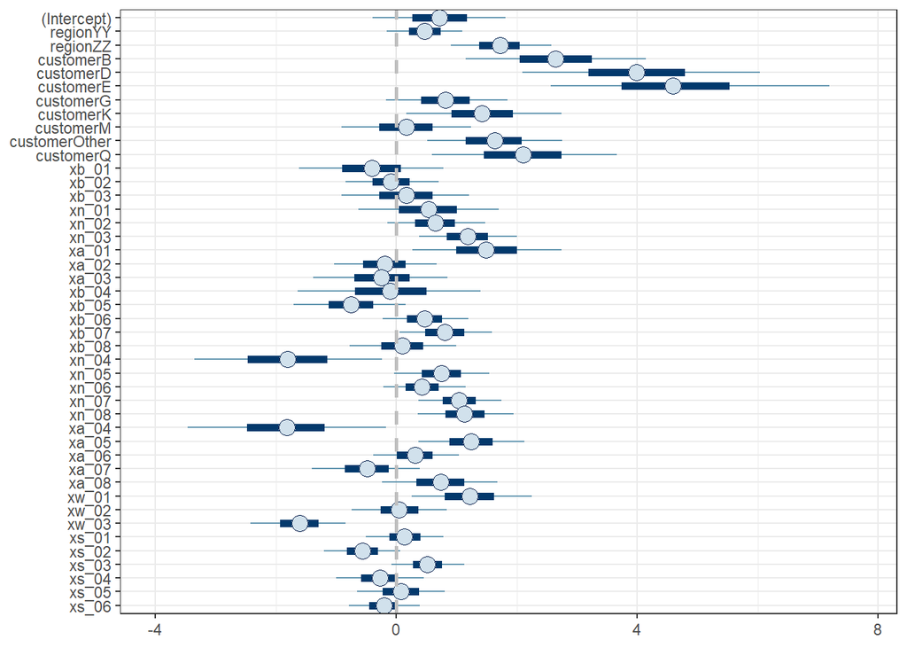

```r
visualize_bayesian_coefficients(bayesian_glm_model3_weak)
```

#### Coefficients significantly different from zero

```r
get_significant_bayesian_coefficients(bayesian_glm_model3_weak)
```

```
## # A tibble: 17 x 3
##    rowname          `5%`  `95%`
##    <chr>           <dbl>  <dbl>
##  1 xa_04         -3.46   -0.167
##  2 xn_04         -3.36   -0.235
##  3 customerE      2.56    7.19
##  4 xw_03         -2.42   -0.842
##  5 customerD      2.09    6.04
##  6 customerB      1.15    4.15
##  7 regionZZ       0.906   2.58
##  8 customerQ      0.591   3.66
##  9 customerOther  0.510   2.75
## 10 xn_03          0.377   2.00
## 11 xn_07          0.370   1.74
## 12 xa_05          0.369   2.13
## 13 xn_08          0.354   1.95
## 14 xa_01          0.268   2.74
## 15 xw_01          0.248   2.25
## 16 customerK      0.165   2.74
## 17 xb_07          0.0533  1.58
```

Like the frequentist models, customer and region show up as high importance features here. Our high-value sentiment features (`xb_07` and `xn_08`) also show up at comparatively low importance, but still significant.

### 3b: strong prior

```r
bayesian_glm_model3_strong <- stan_glm(
  outcome ~ .,
  data = df,
  family = binomial(link = "logit"),
  # prior mean of 0, SD of 1 for the intercept and coefficients
  prior = normal(0, 1),
  prior_intercept = normal(0, 1),
  seed = 2022
)
```

#### Visualize coefficients

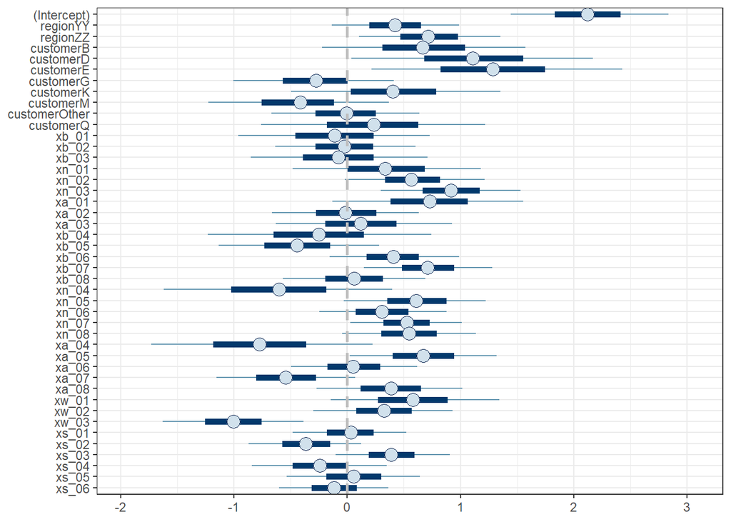

```r
visualize_bayesian_coefficients(bayesian_glm_model3_strong)
```

#### Coefficients significantly different from zero

```r
get_significant_bayesian_coefficients(bayesian_glm_model3_strong)
```

```
## # A tibble: 9 x 3
##   rowname        `5%`  `95%`
##   <chr>         <dbl>  <dbl>
## 1 xw_03       -1.63   -0.384
## 2 (Intercept)  1.44    2.84
## 3 xn_03        0.295   1.53
## 4 customerE    0.215   2.43
## 5 xb_07        0.148   1.28
## 6 regionZZ     0.103   1.35
## 7 customerD    0.0380  2.17
## 8 xn_07        0.0284  1.01
## 9 xa_05        0.0225  1.32
```

Notable here is that a word count feature shows up as significant, which has not been the case for most models evaluated so far.

## Model 9: Cubic sentiment features

Model 9 from section iiiA used cubic features for all sentiment variables. It had strong ROC performance and higher average sensitivity than Model 3 did. Plus it was my idea, which means I’m inordinately attached to it.

Let’s prepare the data and formula:

```r
df_bayesian_glm_model9 <- df %>%
  select(-region, -customer)

formula_terms <- paste("I(", names(df_bayesian_glm_model9) %>% head(-1) ,"^3)", sep = "")
glm_model9_formula <- as.formula(paste("outcome ~", paste(formula_terms, collapse = "+")))
glm_model9_formula
```

```
## outcome ~ I(xb_01^3) + I(xb_02^3) + I(xb_03^3) + I(xn_01^3) +
##     I(xn_02^3) + I(xn_03^3) + I(xa_01^3) + I(xa_02^3) + I(xa_03^3) +
##     I(xb_04^3) + I(xb_05^3) + I(xb_06^3) + I(xb_07^3) + I(xb_08^3) +
##     I(xn_04^3) + I(xn_05^3) + I(xn_06^3) + I(xn_07^3) + I(xn_08^3) +
##     I(xa_04^3) + I(xa_05^3) + I(xa_06^3) + I(xa_07^3) + I(xa_08^3) +
##     I(xw_01^3) + I(xw_02^3) + I(xw_03^3) + I(xs_01^3) + I(xs_02^3) +
##     I(xs_03^3) + I(xs_04^3) + I(xs_05^3) + I(xs_06^3)
## <environment: 0x000000001477af10>
```

### Weak prior

```r
bayesian_glm_model9_weak <-  stan_glm(
  glm_model9_formula,
  data = df_bayesian_glm_model9,
  family = binomial(link = "logit"),
  # prior mean of 0, SD of 4 for the intercept and coefficients
  prior = normal(0, 4),
  prior_intercept = normal(0, 4),
  seed = 2022
)
```

#### Visualize coefficients

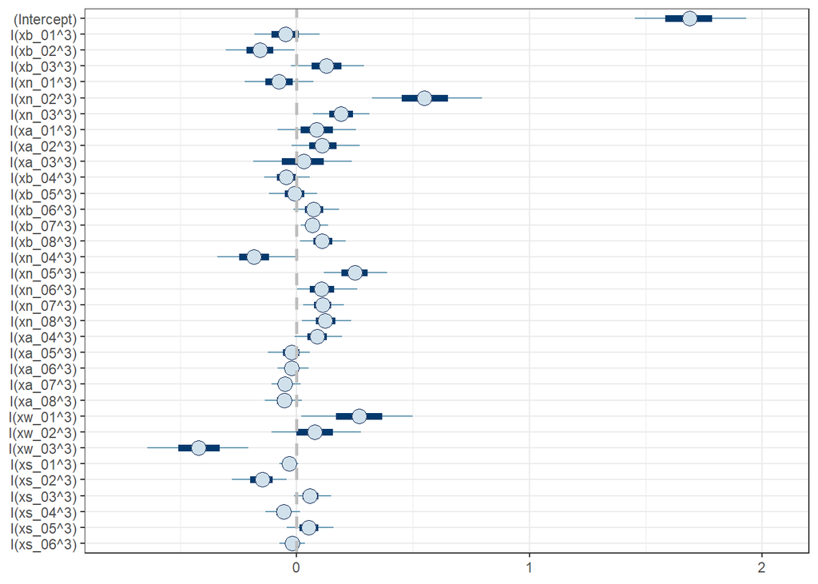

```r
visualize_bayesian_coefficients(bayesian_glm_model9_weak)
```

```r
get_significant_bayesian_coefficients(bayesian_glm_model9_weak)
```

```
## # A tibble: 14 x 3
##    rowname         `5%`    `95%`
##    <chr>          <dbl>    <dbl>
##  1 (Intercept)  1.45     1.93
##  2 I(xw_03^3)  -0.640   -0.206
##  3 I(xn_04^3)  -0.341   -0.00562
##  4 I(xn_02^3)   0.325    0.797
##  5 I(xb_02^3)  -0.304   -0.00926
##  6 I(xs_02^3)  -0.276   -0.0429
##  7 I(xn_05^3)   0.118    0.388
##  8 I(xn_03^3)   0.0710   0.312
##  9 I(xn_07^3)   0.0292   0.204
## 10 I(xn_08^3)   0.0237   0.236
## 11 I(xw_01^3)   0.0201   0.500
## 12 I(xb_07^3)   0.0176   0.136
## 13 I(xb_08^3)   0.0149   0.211
## 14 I(xn_06^3)   0.00175  0.262
```

### Strong prior

```r
bayesian_glm_model9_strong <-  stan_glm(
  glm_model9_formula,
  data = df_bayesian_glm_model9,
  family = binomial(link = "logit"),
  # prior mean of 0, SD of 1 for the intercept and coefficients
  prior = normal(0, 1),
  prior_intercept = normal(0, 1),
  seed = 2022
)
```

#### Visualize coefficients

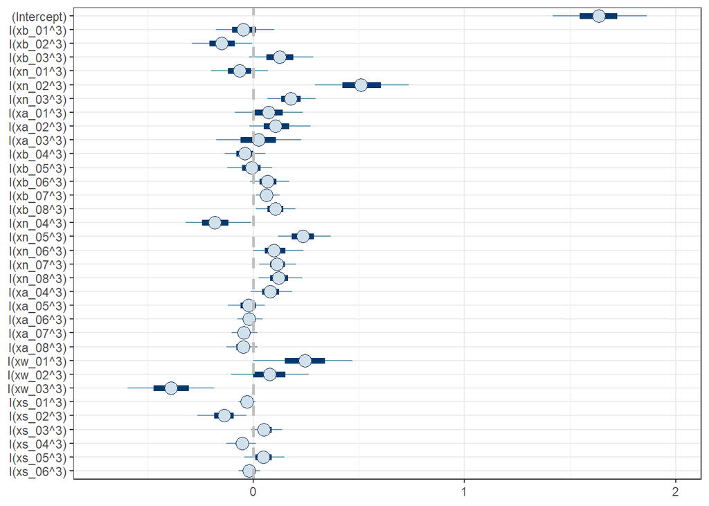

```r
visualize_bayesian_coefficients(bayesian_glm_model9_strong)
```

```r
get_significant_bayesian_coefficients(bayesian_glm_model9_strong)
```

```
## # A tibble: 13 x 3
##    rowname           `5%`    `95%`
##    <chr>            <dbl>    <dbl>
##  1 (Intercept)  1.42       1.86
##  2 I(xw_03^3)  -0.593     -0.184
##  3 I(xn_04^3)  -0.320     -0.0102
##  4 I(xn_02^3)   0.292      0.738
##  5 I(xb_02^3)  -0.289     -0.00572
##  6 I(xs_02^3)  -0.263     -0.0311
##  7 I(xn_05^3)   0.117      0.366
##  8 I(xn_03^3)   0.0668     0.296
##  9 I(xn_07^3)   0.0277     0.203
## 10 I(xn_08^3)   0.0257     0.232
## 11 I(xb_08^3)   0.0132     0.201
## 12 I(xb_07^3)   0.0125     0.125
## 13 I(xw_01^3)   0.0000373  0.469
```

# Comparison

I evaluate these models by computing posterior predictive probabilities and evaluating those. Some of this code is borrowed from a [helpful article on Github](https://avehtari.github.io/modelselection/diabetes.html)

```r
get_posterior_classification_accuracy <- function(model) {
  linpred <- posterior_linpred(model)
  preds <- posterior_epred(model)
  pred <- colMeans(preds)
  pr <- as.integer(pred >= 0.5)

  # mean(pr == as.integer(df$outcome))
  # cbind(pr, ifelse(df$outcome == "event", 1, 0)
  mean(xor(pr,as.integer(df$outcome==0)))
}
```

## Accuracy

### Model 3

#### weak prior

```r
get_posterior_classification_accuracy(bayesian_glm_model3_weak)
```

```
## [1] 0.8788774
```

#### strong prior

```r
get_posterior_classification_accuracy(bayesian_glm_model3_strong)
```

```
## [1] 0.8906942
```

The strong prior seems to help.

### Model 9

#### Weak prior

```r
get_posterior_classification_accuracy(bayesian_glm_model9_weak)
```

```
## [1] 0.9202363
```

#### Strong prior

```r
get_posterior_classification_accuracy(bayesian_glm_model9_strong)
```

```
## [1] 0.9202363
```

By accuracy, the Bayesian formulation of model 9 is the stronger of the two, with the prior strength not helping a ton.

## LOOIC

I’ll be transparent and say that I don’t completely know the intricacies of what’s happening here, but I found this in a vignette about `rstanarm` (available [here](https://mc-stan.org/rstanarm/articles/rstanarm.html)). From this, we can obtain a statistic that is apparently somewhat analogous to a frequentist model’s AIC that does not assume the nature of the posterior distribution.

Model 9 chokes when I try to compute LOOIC, so I only use it to discriminate between versions of model 3.

### Model 3

#### Weak prior

```r
loo(
  bayesian_glm_model3_weak,
  save_psis = TRUE,
  k_threshold = 0.7)
```

```
## 3 problematic observation(s) found.
## Model will be refit 3 times.
```

```
##
## Fitting model 1 out of 3 (leaving out observation 66)
```

```
##
## Fitting model 2 out of 3 (leaving out observation 79)
```

```
##
## Fitting model 3 out of 3 (leaving out observation 475)
```

```
##
## Computed from 4000 by 677 log-likelihood matrix
##
##          Estimate   SE
## elpd_loo   -251.4 17.6
## p_loo        50.0  4.3
## looic       502.7 35.2
## ------
## Monte Carlo SE of elpd_loo is 0.2.
##
## Pareto k diagnostic values:
##                          Count Pct.    Min. n_eff
## (-Inf, 0.5]   (good)     664   98.5%   1188
##  (0.5, 0.7]   (ok)        10    1.5%   2561
##    (0.7, 1]   (bad)        0    0.0%   <NA>
##    (1, Inf)   (very bad)   0    0.0%   <NA>
##
## All Pareto k estimates are ok (k < 0.7).
## See help('pareto-k-diagnostic') for details.
```

#### Strong prior

```r
loo(
  bayesian_glm_model3_strong,
  save_psis = TRUE,
  k_threshold = 0.7)
```

```
## 2 problematic observation(s) found.
## Model will be refit 2 times.
```

```
##
## Fitting model 1 out of 2 (leaving out observation 66)
```

```
##
## Fitting model 2 out of 2 (leaving out observation 475)
```

```
##
## Computed from 4000 by 677 log-likelihood matrix
##
##          Estimate   SE
## elpd_loo   -244.0 15.6
## p_loo        35.9  2.8
## looic       488.1 31.2
## ------
## Monte Carlo SE of elpd_loo is 0.1.
##
## Pareto k diagnostic values:
##                          Count Pct.    Min. n_eff
## (-Inf, 0.5]   (good)     671   99.4%   1586
##  (0.5, 0.7]   (ok)         4    0.6%   2666
##    (0.7, 1]   (bad)        0    0.0%   <NA>
##    (1, Inf)   (very bad)   0    0.0%   <NA>
##
## All Pareto k estimates are ok (k < 0.7).
## See help('pareto-k-diagnostic') for details.
```

This is inconclusive, since the standard error of the LOOIC statistic overlaps between the two models.

## WAIC

Since we need a way to compare complexity between models 3 and 9, I turned to WAIC.

```r
bayesian_glm_model3_weak$waic <- waic(bayesian_glm_model3_weak)
bayesian_glm_model3_strong$waic <- waic(bayesian_glm_model3_strong)
bayesian_glm_model9_weak$waic <- waic(bayesian_glm_model9_weak)
bayesian_glm_model9_strong$waic <- waic(bayesian_glm_model9_strong)
all_models <- stanreg_list(
  bayesian_glm_model3_weak,
  bayesian_glm_model3_strong,
  bayesian_glm_model9_weak,
  bayesian_glm_model9_strong,
  model_names = c(
    "Linear additive, all features (weak prior)",
    "Linear additive, all features (strong prior)",
    "Cubic sentiment features (weak prior)",
    "Cubic sentiment features (strong prior)"
  )
)

loo_compare(all_models, criterion = "waic")
```

```
## Model comparison based on WAIC:
##                                              elpd_diff se_diff
## Linear additive, all features (strong prior)   0.0       0.0
## Linear additive, all features (weak prior)    -6.5       4.5
## Cubic sentiment features (strong prior)      -27.8      10.4
## Cubic sentiment features (weak prior)        -29.8      10.7
```

# Deeper look at the best model (Model 3, strong prior)

## Coefficient distributions

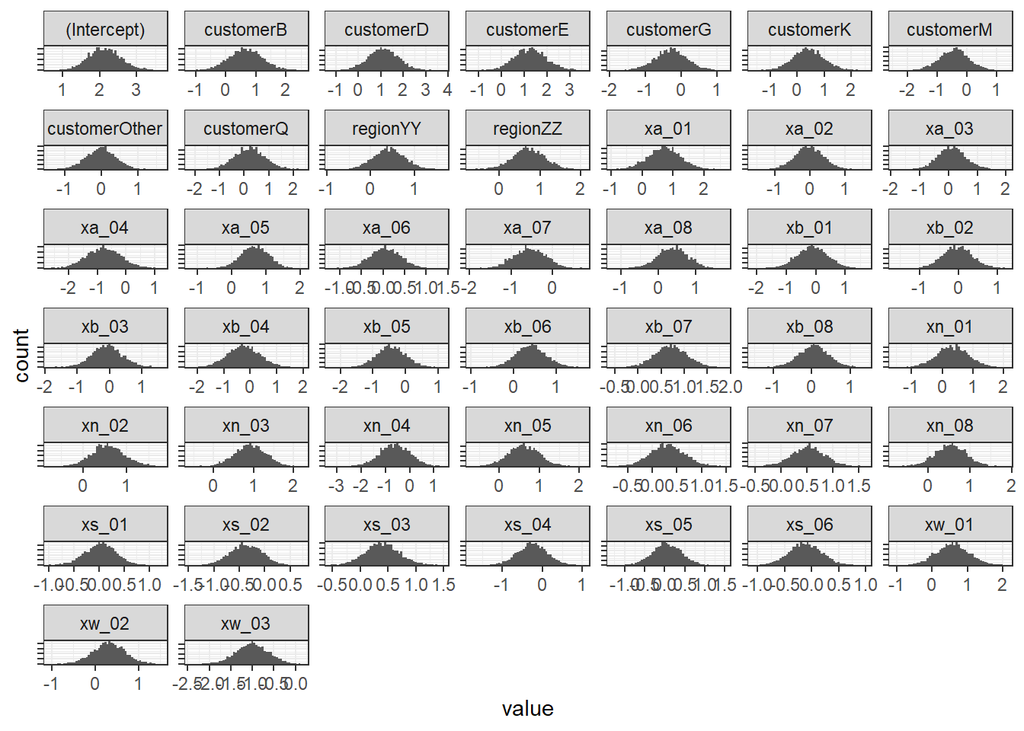

```r
# options(repr.plot.width = 1, repr.plot.height = 5)
as.data.frame(bayesian_glm_model3_strong) %>%
  tibble::as_tibble() %>%
  select(all_of(names(bayesian_glm_model3_strong$coefficients))) %>%
  tibble::rowid_to_column("post_id") %>%
  pivot_longer(!c("post_id")) %>%
  ggplot(mapping = aes(x = value)) +
  geom_histogram(bins = 55) +
  facet_wrap(~name, scales = "free") +
  theme_bw() +
  theme(axis.text.y = element_blank())
```

It’s hard to see (I can’t figure out how to resize facet grid stuff), but most parameters appear to have Gaussian posterior distributions. We can also examine posterior correlation among the variables:

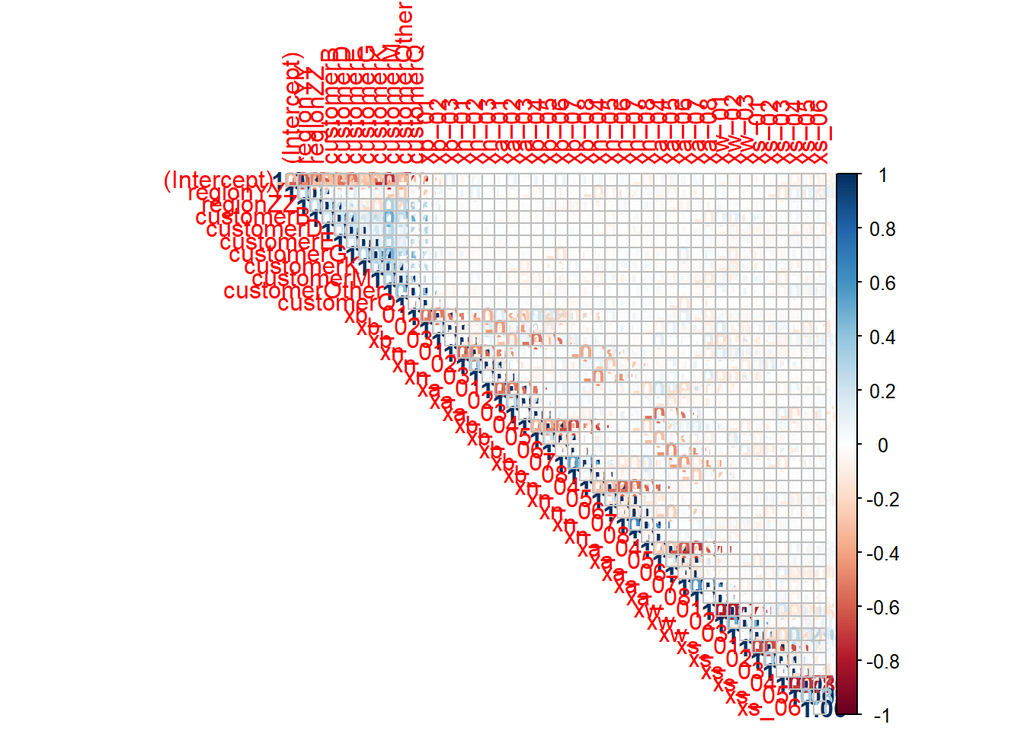

```r
bayesian_glm_model3_strong %>%
  tibble::as_tibble() %>%
  select(all_of(names(bayesian_glm_model3_strong$coefficients))) %>%
  cor %>%
  corrplot::corrplot(type = "upper", method = "number")
```

This is a lot of predictors, but they mostly all seem to be contributing. There is high correlation with the intercept in some cases.